### Load data and packages

```r
library(randomForest)
library(pdp)
library(caret)
library(tidyverse)
library(ggpubr)
library(caret)
library(stringr)
library(here)
library(janitor)

mcf <- read.csv('Zaca MCF variables for model.csv') %>%
  select('drainage_assoication', 'ridge', 'mortality',
         'prefire','mortality_qual', 'canopy_loss_success',
         'canopy_loss_failure', 'postfire_canopy', 'postfire',
         'Change_in_canopy_success', 'Change_in_canopy_failure',
         'Change_Qualitative','high_mortality', 'area_scaled',
         'dem_10m_zaca', 'flow_accumulation', 'sr', 'sr_new',
         'rain', 'slope', 'tmax', 'tmean', 'tmin', 'TPI_five',
         'TPI_queen', 'TWI', 'fri', 'dem_scaled', 'southness' ) %>%
  mutate(mortality_qual= fct_relevel(mortality_qual,
                                     levels=c("None", "Low", "Moderate", "High")))
```

### Sample Size for each mortality class

```r
mortality_count <- mcf %>%
  group_by(mortality_qual) %>%
  count()

mortality_count
```

```
## # A tibble: 4 x 2
## # Groups:   mortality_qual [4]
##   mortality_qual     n
##   <fct>          <int>
## 1 None             251
## 2 Low              166
## 3 Moderate         160
## 4 High             158
```

### Data Spread

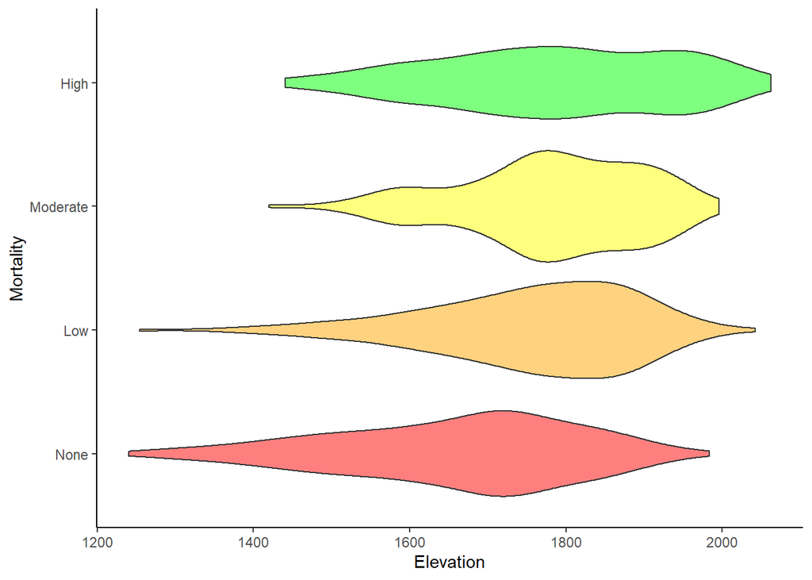

```r
solar_rad_mcf <- ggplot(mcf, aes(x=mortality_qual, y=sr, fill=mortality_qual))+
  geom_violin(alpha=0.5, show.legend=F) +
  theme_classic() +
  labs(x="Mortality", y="Solar Radiation") +
  scale_fill_manual(values=c("red", "orange", "yellow", "green")) +
  coord_flip()

tmax_mcf <- ggplot(mcf, aes(x=mortality_qual, y=tmax, fill=mortality_qual))+
  geom_violin(alpha=0.5, show.legend=F) +
  theme_classic() +
  labs(x="Mortality", y="Max Aug Temp (celcius)") +
  scale_fill_manual(values=c("red", "orange", "yellow", "green")) +
  coord_flip()

rain_mcf <- ggplot(mcf, aes(x=mortality_qual, y=rain, fill=mortality_qual))+
  geom_violin(alpha=0.5, show.legend=F) +
  theme_classic() +
  labs(x="Mortality", y="Precipitation") +
  scale_fill_manual(values=c("red", "orange", "yellow", "green")) +
  coord_flip()

tpi_mcf <- ggplot(mcf, aes(x=mortality_qual, y=TPI_five, fill=mortality_qual))+
  geom_violin(alpha=0.5, show.legend=F) +
  theme_classic() +
  labs(x="Mortality", y="TPI") +
  scale_fill_manual(values=c("red", "orange", "yellow", "green")) +
  coord_flip()

twi_mcf <- ggplot(mcf, aes(x=mortality_qual, y=TWI, fill=mortality_qual))+
  geom_violin(alpha=0.5, show.legend=F) +
  theme_classic() +
  labs(x="Mortality", y="TWI") +
  scale_fill_manual(values=c("red", "orange", "yellow", "green")) +
  coord_flip()

slope_mcf <- ggplot(mcf, aes(x=mortality_qual, y=slope, fill=mortality_qual))+
  geom_violin(alpha=0.5, show.legend=F) +
  theme_classic() +
  labs(x="Mortality", y="Slope") +
  scale_fill_manual(values=c("red", "orange", "yellow", "green")) +
  coord_flip()

elev_mcf <- ggplot(mcf, aes(x=mortality_qual, y=dem_10m_zaca, fill=mortality_qual))+
  geom_violin(alpha=0.5, show.legend=F) +
  theme_classic() +
  labs(x="Mortality", y="Elevation") +
  scale_fill_manual(values=c("red", "orange", "yellow", "green")) +
  coord_flip()
elev_mcf
```

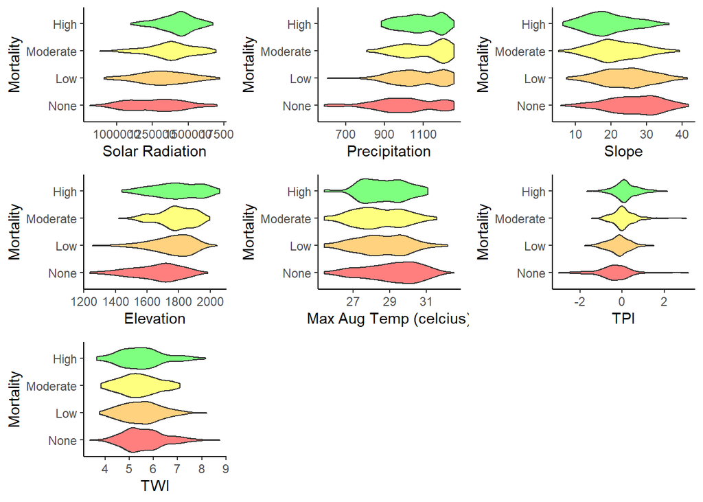

```r
ggarrange(solar_rad_mcf, rain_mcf, slope_mcf, elev_mcf, tmax_mcf, tpi_mcf, twi_mcf)
```

```r
#ggsave("zaca MCF most important variable violin plots.png")
```

Most distinction between classes in slope, elevation, and solar radiation. Could explain why those variables tend to have the highest variable importance. Interestingly, stands with higher elevation had higher mortality and stands with steeper slope and higher max temp had lower/no mortality. Both of which are counter-intuitive.

### Random Forest

Which variables contribute to mortality?

Literature review:

```r
# lists to save outputs from for loop---------------------------------------------

test_accuracy_list <- list()
test_table_accuracy_list <- list()

#random forest code---------------------------------------------------
for (i in 1:100)
{

  # divide data into equal # of observations --------------------

  mcf_high <- mcf[which(mcf$mortality_qual == "High"),]
  mcf_low <- mcf[which(mcf$mortality_qual == "Low"),]
  mcf_moderate <- mcf[which(mcf$mortality_qual == "Moderate"),]
  mcf_none <- mcf[which(mcf$mortality_qual == "None"),]

  # pull random observations from the high class and separate
  x_high <- sample(1:nrow(mcf_high), 125 , replace = FALSE)
  polygon_data_high_train <- mcf_high[x_high,]
  polygon_data_high_test <- mcf_high[-x_high,]
  # pull random observations from the low class and separate
  x_low <- sample(1:nrow(mcf_low), 125 , replace = FALSE)
  polygon_data_low_train <- mcf_low[x_low,]
  polygon_data_low_test <- mcf_low[-x_low,]
  # pull random observations from the moderate class and separate
  x_moderate <- sample(1:nrow(mcf_moderate), 125 , replace = FALSE)
  polygon_data_moderate_train <- mcf_moderate[x_moderate,]
  polygon_data_moderate_test <- mcf_moderate[-x_moderate,]
  # pull random observations from the none class and separate
  x_none <- sample(1:nrow(mcf_none), 125 , replace = FALSE)
  polygon_data_none_train <- mcf_none[x_none,]
  polygon_data_none_test <- mcf_none[-x_none,]

  # combine all random observations
  train <- do.call("rbind", list(polygon_data_none_train, polygon_data_low_train, polygon_data_moderate_train, polygon_data_high_train))
  # recombine classes that were not pulled
  test <- do.call("rbind", list(polygon_data_none_test, polygon_data_low_test, polygon_data_moderate_test, polygon_data_high_test))

  #random forest model
  rfm<-randomForest(mortality_qual~ rain + tmax + TPI_five + dem_10m_zaca + flow_accumulation + sr + slope + TWI, data = train, ntree=500, importance=T, nscale=0)

  rfm

  #plot to visualize variable importance
  #varImpPlot(rfm)
  model_importance <- importance(rfm)

  #predcit test data
  pp<-predict(rfm, test)

  #test data accuracy
  tabb<- table(pp, test$mortality_qual)
  tabb
  test_table_accuracy_list <- append(test_table_accuracy_list, tabb)
  acc<-1-sum(diag(tabb))/sum(tabb)
  acc #% missclassified
  test_accuracy <-(1-acc)*100 #model accuracy

  # lists to save model accuracys
  test_accuracy_list <- append(test_accuracy_list, test_accuracy)

  write.table(model_importance, file="rfm model importance.csv", sep=",",col.names=NA, append=T) #if change the variable inputs, have to remember to delete the rfm importance csv file otherwise r will keep adding the values onto the orignial and not make a new one. or can just change the csv file name
}

accuracy_df <- as.data.frame(unlist(test_accuracy_list))
test_table_accuracy_list_df <- as.data.frame(unlist(test_table_accuracy_list))

#idk why this isnt working now.
mean_test_accuracy_1 <- accuracy_df %>%
  mutate(test_accuracy_list = as.numeric(test_accuracy_list)) %>%
  summarize(mean_accuracy = mean(unlist(test_accuracy_list)))
```

```r
# read in model importance table and make it R friendly
model_importance_tidy <- read_csv(here("Model Data Sheets and Code", "rfm model importance.csv")) %>%
  clean_names() %>%
  filter(none != "None") %>%
  rename (variables = x1) %>%
  mutate (variables = str_to_lower(variables)) %>%
  mutate (none = as.numeric(none),
          low = as.numeric(low),
          moderate = as.numeric(moderate),
          high = as.numeric(high),
          mean_decrease_accuracy = as.numeric(mean_decrease_accuracy),
          mean_decrease_gini = as.numeric(mean_decrease_gini)
          )
# model importance summary statistics

model_importance_summary <- model_importance_tidy %>%
  group_by(variables) %>%
  summarize (none_mean = mean(none),
             low_mean = mean(low),
             moderate_mean = mean(moderate),
             high_mean = mean(high),
             mean_dec_accuracy_mean = mean(mean_decrease_accuracy),
             mean_decrease_gini_mean = mean(mean_decrease_gini)
  )
```

### Random Forest Model with 3 mortality classes

No and low mortality are pretty similar and both would be ideal for land managers.

```r
# sub data --------------------------------------------------------------

mcf_3 <- mcf %>%
  mutate(three_class_mortality = case_when(
    mortality_qual %in% "High" ~ "High",
    mortality_qual %in% "Moderate" ~ "Moderate",
    mortality_qual %in% c("Low", "None") ~ "Low"
  )) %>%
  mutate(three_class_mortality = as.factor(three_class_mortality)) %>%
  mutate(three_class_mortality= fct_relevel(three_class_mortality,
                                     levels=c("Low", "Moderate", "High")))

# lists to save outputs from for loop---------------------------------------------

test_accuracy_list <- list()

#random forest code---------------------------------------------------
for (i in 1:100)
{

  # divide data into equal # of observations --------------------

  mcf_high <- mcf_3[which(mcf_3$three_class_mortality == "High"),]
  mcf_low <- mcf_3[which(mcf_3$three_class_mortality == "Low"),]
  mcf_moderate <- mcf_3[which(mcf_3$three_class_mortality == "Moderate"),]

  # pull random observations from the high class and separate
  x_high <- sample(1:nrow(mcf_high), 120 , replace = FALSE)
  polygon_data_high_train <- mcf_high[x_high,]
  polygon_data_high_test <- mcf_high[-x_high,]
  # pull random observations from the low class and separate
  x_low <- sample(1:nrow(mcf_low), 120 , replace = FALSE)
  polygon_data_low_train <- mcf_low[x_low,]
  polygon_data_low_test <- mcf_low[-x_low,]
  # pull random observations from the moderate class and separate
  x_moderate <- sample(1:nrow(mcf_moderate), 120 , replace = FALSE)
  polygon_data_moderate_train <- mcf_moderate[x_moderate,]
  polygon_data_moderate_test <- mcf_moderate[-x_moderate,]

  # combine all random observations
  train <- do.call("rbind", list(polygon_data_low_train, polygon_data_moderate_train, polygon_data_high_train))
  # recombine classes that were not pulled
  test <- do.call("rbind", list(polygon_data_low_test, polygon_data_moderate_test, polygon_data_high_test))

  #random forest model
  rfm<-randomForest(three_class_mortality~ rain + tmax + TPI_five + dem_10m_zaca + flow_accumulation + sr + slope + TWI, data = train, ntree=500, importance=T, nscale=0)

  rfm

  #plot to visualize variable importance
  model_importance <- importance(rfm)
  write.table(model_importance, file="rfm model importance_3 class mortality.csv", sep=",",col.names=NA, append=T)
  #varImpPlot(rfm)

  #predcit test data
  pp<-predict(rfm, test)

  #test data accuracy
  tabb<- table(pp, test$three_class_mortality)
  tabb
  test_table_accuracy_list <- append(test_table_accuracy_list, tabb)
  acc<-1-sum(diag(tabb))/sum(tabb)
  acc #% missclassified
  test_accuracy <-(1-acc)*100 #model accuracy

  # lists to save model accuracys
  test_accuracy_list <- append(test_accuracy_list, test_accuracy)
}

accuracy_df <- as.data.frame(unlist(test_accuracy_list))
test_table_accuracy_list_df <- as.data.frame(unlist(test_table_accuracy_list))

mean_test_accuracy_1 <- accuracy_df %>%
  summarize(mean_accuracy = mean(unlist(test_accuracy_list)))


# read in model importance table and make it R friendly
model_importance_tidy <- read_csv(here("Model Data Sheets and Code", "rfm model importance_3 class mortality.csv")) %>%
  clean_names() %>%
  filter(low != "Low") %>%
  rename (variables = x1) %>%
  mutate (variables = str_to_lower(variables)) %>%
  mutate (low = as.numeric(low),
          moderate = as.numeric(moderate),
          high = as.numeric(high),
          mean_decrease_accuracy = as.numeric(mean_decrease_accuracy),
          mean_decrease_gini = as.numeric(mean_decrease_gini)
          )

# model importance summary statistics

model_importance_summary <- model_importance_tidy %>%
  group_by(variables) %>%
  summarize (low_mean = mean(low),
             moderate_mean = mean(moderate),
             high_mean = mean(high),
             mean_dec_accuracy_mean = mean(mean_decrease_accuracy),
             mean_decrease_gini_mean = mean(mean_decrease_gini)
  )
```

### Random Forest via Cross Validation

code from: https://www.youtube.com/watch?v=84JSk36og34

```r
# equal number of observations
  mcf_high <- mcf[which(mcf$mortality_qual == "High"),]
  mcf_low <- mcf[which(mcf$mortality_qual == "Low"),]
  mcf_moderate <- mcf[which(mcf$mortality_qual == "Moderate"),]
  mcf_none <- mcf[which(mcf$mortality_qual == "None"),]

  # pull random observations from the high class and separate
  x_high <- sample(1:nrow(mcf_high), 158 , replace = FALSE)
  polygon_data_high_train <- mcf_high[x_high,]
  polygon_data_high_test <- mcf_high[-x_high,]
  # pull random observations from the low class and separate
  x_low <- sample(1:nrow(mcf_low), 158 , replace = FALSE)
  polygon_data_low_train <- mcf_low[x_low,]
  polygon_data_low_test <- mcf_low[-x_low,]
  # pull random observations from the moderate class and separate
  x_moderate <- sample(1:nrow(mcf_moderate), 158 , replace = FALSE)
  polygon_data_moderate_train <- mcf_moderate[x_moderate,]
  polygon_data_moderate_test <- mcf_moderate[-x_moderate,]
  # pull random observations from the none class and separate
  x_none <- sample(1:nrow(mcf_none), 158 , replace = FALSE)
  polygon_data_none_train <- mcf_none[x_none,]
  polygon_data_none_test <- mcf_none[-x_none,]

  # combine all random observations
  train <- do.call("rbind", list(polygon_data_none_train, polygon_data_low_train, polygon_data_moderate_train, polygon_data_high_train))
  # recombine classes that were not pulled
  test <- do.call("rbind", list(polygon_data_none_test, polygon_data_low_test, polygon_data_moderate_test, polygon_data_high_test))
# make sure y variable is recgonized as a factor
mortality_qual <- as.factor(mcf$mortality_qual)

#add explanatory variables to a single data frame
explantory_variables <- mcf %>%
  select(rain, tmax,TPI_five,dem_10m_zaca,flow_accumulation,sr,slope,TWI)

# create folds
folds <-  createMultiFolds(mortality_qual, k=10, times=10)

# train Control
control <- trainControl(method = "repeatedcv", number = 10, repeats = 10, index = folds, savePredictions = T)

# cross validation model for random forest
rf.cv <- train(x= explantory_variables, y=mortality_qual, method="rf", tuneLength = 2, ntree=500, trControl=control)

# summary statistics
rf.cv
```

```
## Random Forest
##
## 735 samples
##   8 predictor
##   4 classes: 'None', 'Low', 'Moderate', 'High'
##
## No pre-processing
## Resampling: Cross-Validated (10 fold, repeated 10 times)
## Summary of sample sizes: 661, 662, 661, 663, 661, 661, ...
## Resampling results across tuning parameters:
##
##   mtry  Accuracy   Kappa
##   2     0.4765696  0.2826526
##   8     0.4585290  0.2588035
##
## Accuracy was used to select the optimal model using the largest value.
## The final value used for the model was mtry = 2.
```

### Chris’ modified binomial model (original code??)

### Chris’ modified binomial model (modified by amp)

```r
# train and test data
  mcf_high <- mcf[which(mcf$mortality_qual == "High"),]
  mcf_low <- mcf[which(mcf$mortality_qual == "Low"),]
  mcf_moderate <- mcf[which(mcf$mortality_qual == "Moderate"),]
  mcf_none <- mcf[which(mcf$mortality_qual == "None"),]

  # pull random observations from the high class and separate
  x_high <- sample(1:nrow(mcf_high), 125 , replace = FALSE)
  polygon_data_high_train <- mcf_high[x_high,]
  polygon_data_high_test <- mcf_high[-x_high,]
  # pull random observations from the low class and separate
  x_low <- sample(1:nrow(mcf_low), 125 , replace = FALSE)
  polygon_data_low_train <- mcf_low[x_low,]
  polygon_data_low_test <- mcf_low[-x_low,]
  # pull random observations from the moderate class and separate
  x_moderate <- sample(1:nrow(mcf_moderate), 125 , replace = FALSE)
  polygon_data_moderate_train <- mcf_moderate[x_moderate,]
  polygon_data_moderate_test <- mcf_moderate[-x_moderate,]
  # pull random observations from the none class and separate
  x_none <- sample(1:nrow(mcf_none), 125 , replace = FALSE)
  polygon_data_none_train <- mcf_none[x_none,]
  polygon_data_none_test <- mcf_none[-x_none,]

  # combine all random observations
  train <- do.call("rbind", list(polygon_data_none_train, polygon_data_low_train, polygon_data_moderate_train,  polygon_data_high_train))
  # recombine classes that were not pulled
  test <- do.call("rbind", list(polygon_data_none_test, polygon_data_low_test, polygon_data_moderate_test, polygon_data_high_test))

#model
blr <- glm(cbind(canopy_loss_success, canopy_loss_failure) ~ TPI_five + sr + prefire, family = binomial(link = "logit"), data = train)

#model outputs
blr
```

```
##
## Call:  glm(formula = cbind(canopy_loss_success, canopy_loss_failure) ~
##     TPI_five + sr + prefire, family = binomial(link = "logit"),
##     data = train)
##
## Coefficients:
##   (Intercept)       TPI_five             sr   prefire25_75  prefire75_100
##    -3.546e+00      7.132e-01      2.098e-06      1.529e-01      4.347e-01
##
## Degrees of Freedom: 499 Total (i.e. Null);  495 Residual
## Null Deviance:       208000
## Residual Deviance: 167900    AIC: 170600
```

```r
summary(blr)
```

```
##
## Call:
## glm(formula = cbind(canopy_loss_success, canopy_loss_failure) ~
##     TPI_five + sr + prefire, family = binomial(link = "logit"),
##     data = train)
##
## Deviance Residuals:
##     Min       1Q   Median       3Q      Max
## -46.481  -16.732    0.132   13.198   46.411
##
## Coefficients:
##                 Estimate Std. Error z value Pr(>|z|)
## (Intercept)   -3.546e+00  2.852e-02 -124.30   <2e-16 ***
## TPI_five       7.132e-01  4.993e-03  142.84   <2e-16 ***
## sr             2.098e-06  1.916e-08  109.47   <2e-16 ***
## prefire25_75   1.529e-01  9.849e-03   15.53   <2e-16 ***
## prefire75_100  4.347e-01  1.016e-02   42.78   <2e-16 ***
## ---
## Signif. codes:  0 '***' 0.001 '**' 0.01 '*' 0.05 '.' 0.1 ' ' 1
##
## (Dispersion parameter for binomial family taken to be 1)
##
##     Null deviance: 208012  on 499  degrees of freedom
## Residual deviance: 167892  on 495  degrees of freedom
## AIC: 170610
##
## Number of Fisher Scoring iterations: 5
```

```r
#predict
prob <- predict(blr, newdata = test, type = "response")

# ifelse code to get probabilities
class_out <- ifelse(prob < 0.25, "None",
                    ifelse(prob < 0.5, "Low",
                           ifelse(prob < 0.75, " Moderate",
                                  ifelse(prob <1, "High"))))
model_predictions <- enframe(class_out, name= "Observation Num", value="class_out")
model_predictions <- data.frame(model_predictions) %>%
  mutate(class_out, fct_relevel(class_out, levels=c("None", "Low", "Moderate", "High")))
table(Predicted = model_predictions$class_out, Actual = test$canopy_loss_success)
```

```
##            Actual
## Predicted    0 250 500 750
##    Moderate  6   3   5  12
##   High       2   0   0   1
##   Low       69  27  28  21
##   None      48  10   1   2
```

Notes:

- I changed the response varaible from the difference in pre and post fire canopy cover (in your data its the postfire success/failure, in my data its the change in canopy success/failure), to fire induced canopy loss (i.e. mortality) success/failure
- also split up the data into train and test data with an equal number of observations in each mortality class for the train data. The model kept confusing the mortality with low/none since none had such a higher number of observations

### Future Models

Chose the GFDL-CM3 model which is from the NOAA Geophysical Fluid Dynamics Laboratory. Wasn’t sure which one to pick, but NOAA is a reputable organization.

- LOCA VIR RUN (Scripps): Has monthly data for RCP 4.5 and 8.5 for precipitation and “air temperature”"
- LOCA Downscaled CMIP5 Climate Projections (Scripps): daily and annual data for RCP 4.5 and 8.5 (no monthly data) for min temp, max temp, precip, solar radiation, relative humidity
- LOCA Derived Products: mixture of things. RCP 4.5 and 8.5. No monthly data for climate variables